# **Dasar *R***[^2]

## 4.1 *Histogram*

Histogram menampilkan distribusi probabilitas (*frequency*) dan densitas (*density*) dari data (*continous variabel*).

- Sintaks *histogram*: `hist(variable)`.

**a. *Histogram* Frekuensi**

- *histogram* dari kolom atau *variable* “DBH”.

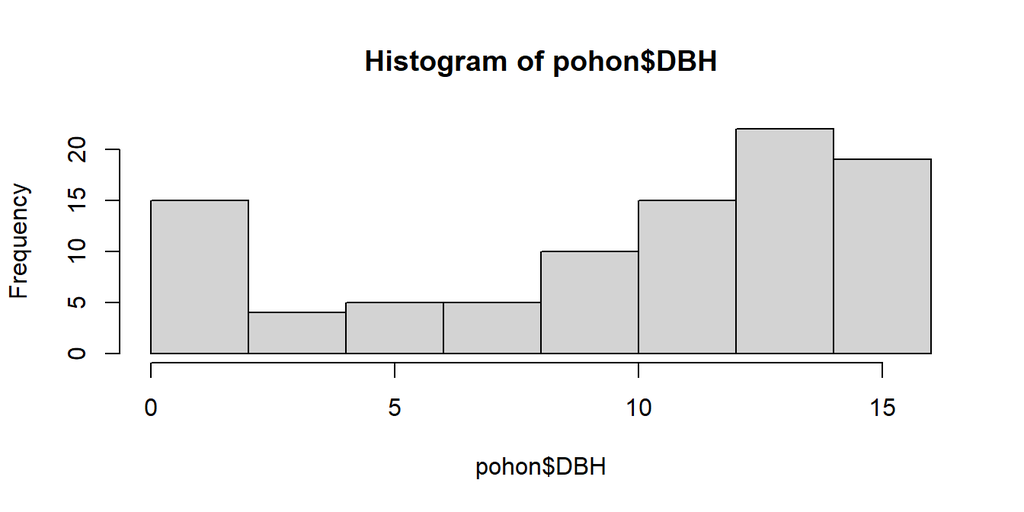

```r
hist(pohon$DBH)
```

- memberikan label nilai pada *histogram* di atas, tambahan *parameter* `labels=T`.

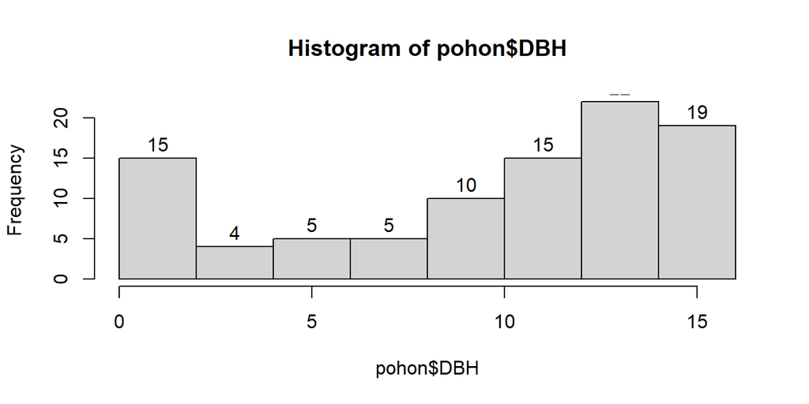

```r
hist(pohon$DBH, labels = T)
```

- mengatur batas sumbu y (*y-axis*), tambahan *parameter* `ylim=c(batas bawah, batas atas)`.

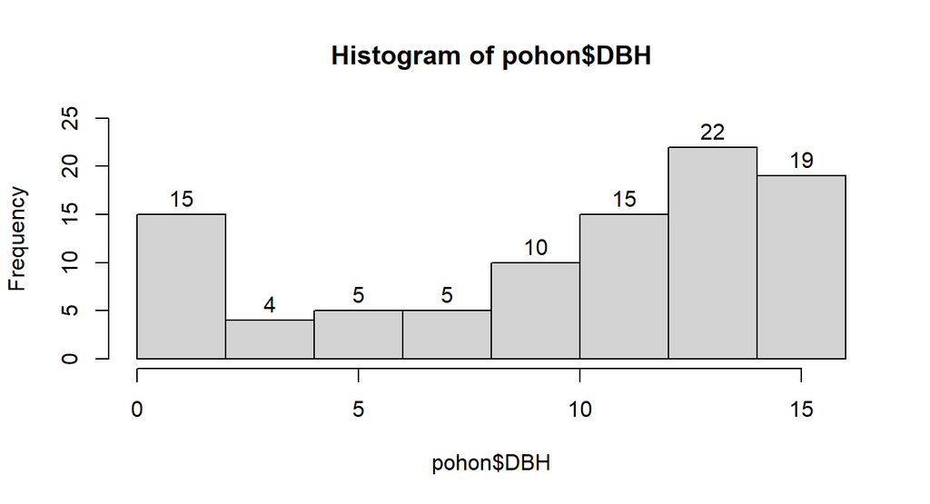

```r
hist(pohon$DBH, labels = T, ylim = c(0, 25))
```

- mengatur jumlah kelompok sumbu X, tambahan parameter `breaks=jumlah_breaks`.

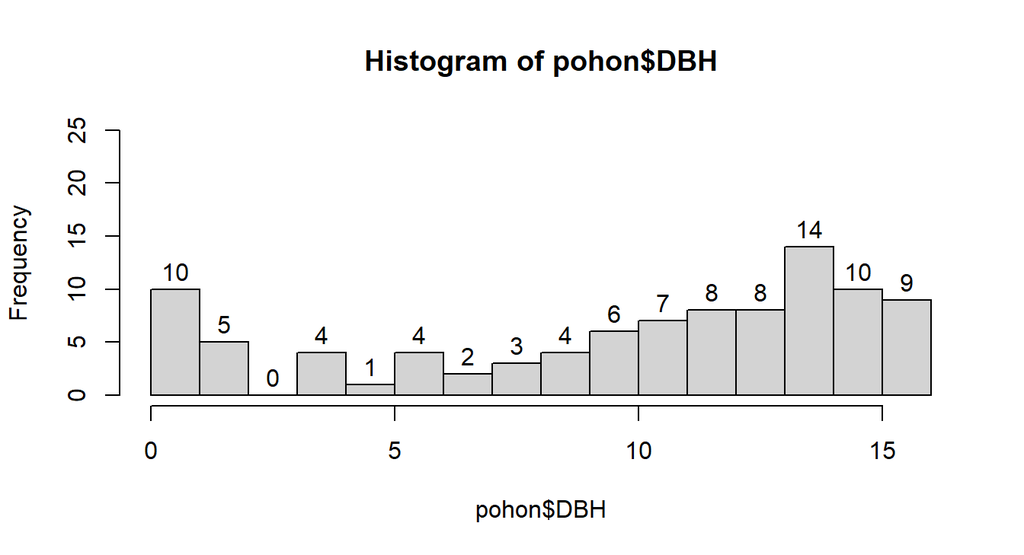

```r
hist(pohon$DBH, labels = T, ylim = c(0, 25), breaks = 15)
```

- menambahkan judul *histogram*, tambahan *parameter* `main="judul_histogram"`.

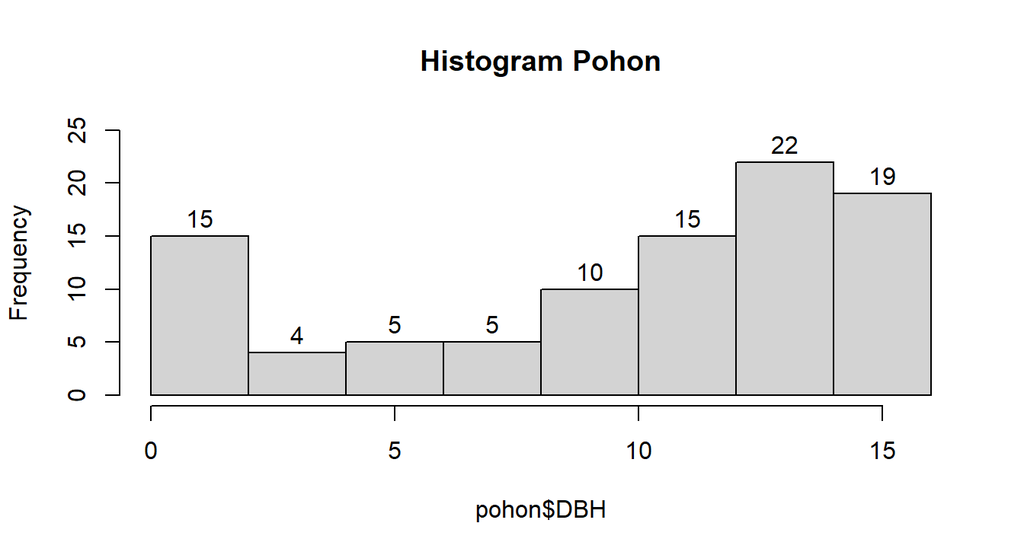

```r
hist(pohon$DBH, labels = T, ylim = c(0, 25), main = "Histogram Pohon")
```

- mengubah nama sumbu X (`xlab="nama_sumbu_x"`) dan sumbu Y (`ylab="nama_sumbu_y"`).

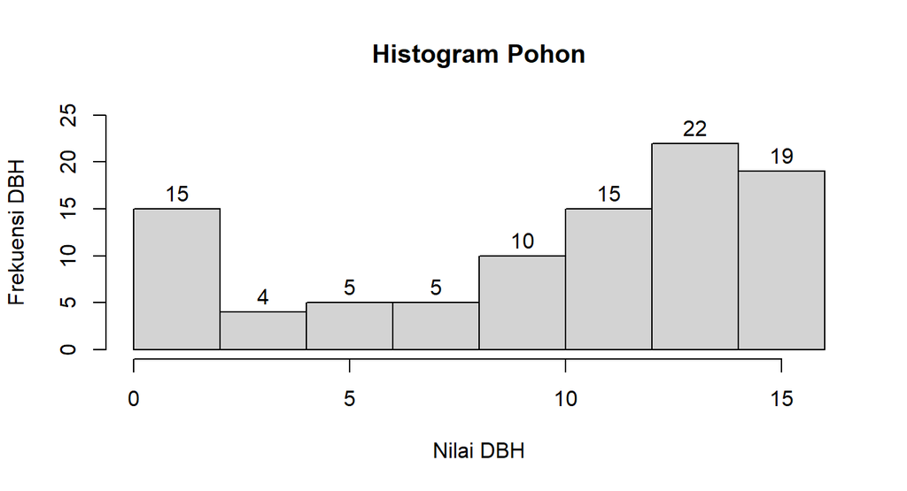

```r
hist(pohon$DBH, labels = T, ylim = c(0, 25), main = "Histogram Pohon",
    xlab = "Nilai DBH", ylab = "Frekuensi DBH")
```

- mewarnai *bar histogram* (`col="warna"`) dan batas *bar histogram* (`border="warna"`).

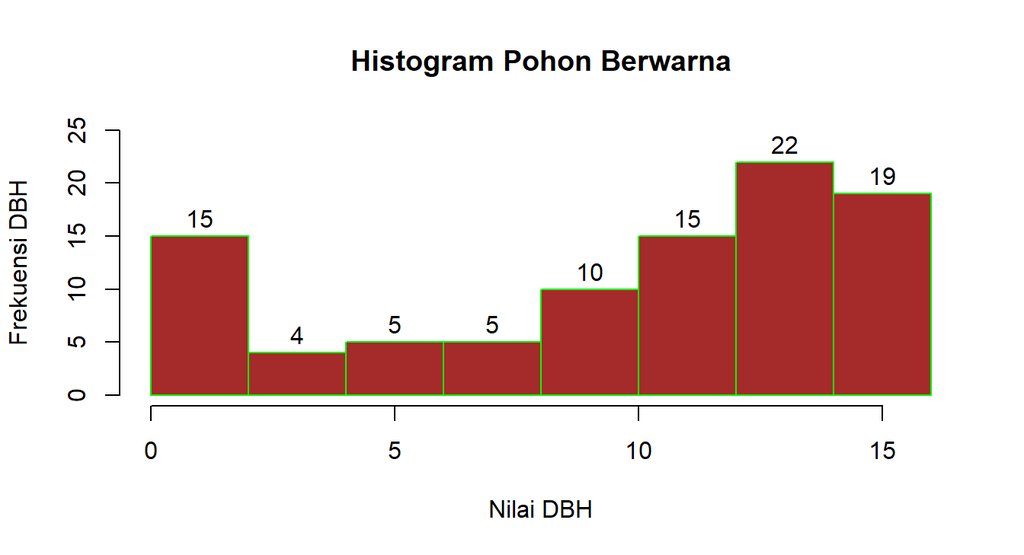

```r
hist(pohon$DBH, labels = T, ylim = c(0, 25), main = "Histogram Pohon Berwarna",
    xlab = "Nilai DBH", ylab = "Frekuensi DBH", col = "brown",
    border = "green")
```

- pilihan lain: memberikan warna-warni yang berbeda pada setiap *bar histogram* (perhatikan tambahan *parameter* `col=c(1:8)`.

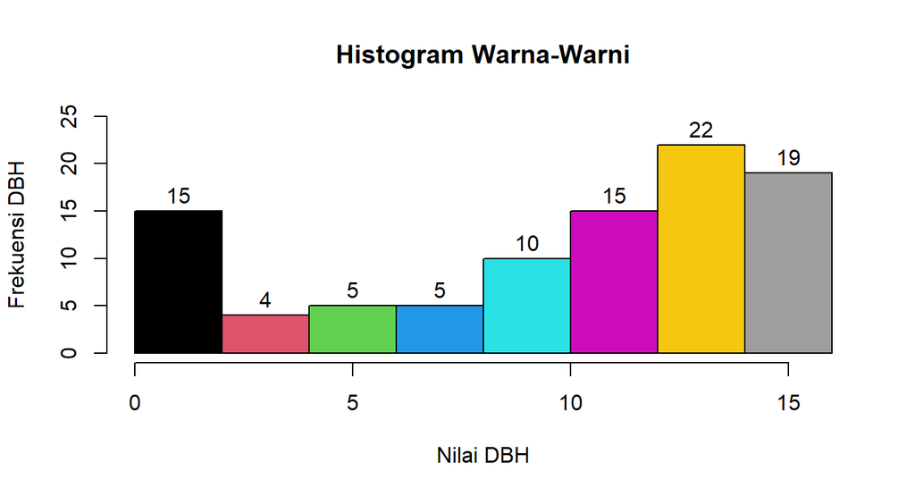

```r
hist(pohon$DBH, labels = T, ylim = c(0, 25), main = "Histogram Warna-Warni",
    xlab = "Nilai DBH", ylab = "Frekuensi DBH", col = c(1:8))
```

**b. *Histogram Probability Density***